# Hydrometeorological Data from ETESA

M. G. Castrellon

June 16th, 2019

The Purpose of this document is to illustrate the data exploration and cleaning process that I do to prepare the Panamanian hydrometeorological data from ETESA to be used in different applications such as ET estimation and hydrological modeling. The raw data from ETESA’s Department of hydrometeorology can be donwloaded from their open data online portal (http://hidromet.com.pa/open_data.php). The data is open and public, but the site requires the user to register previous to access the data.

```r
# Required Libraries
library(tidyverse)
library(lubridate)

# Load Functions
source("ETESA_Functions.R")
```

# Data Exploration

The first thing to do with ETESA Data is to identify and assign the missing data, because what they usually do is skip the date and times when there is no data. In the the function `AssignMissingValues()` was built to identify gaps missing dates in the data and assign missing values.

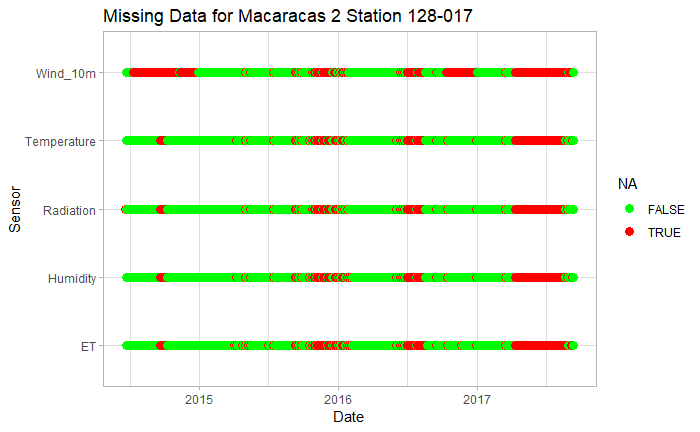

```r
# Load Data
file_path <- "C:/Users/mgcastre/Dropbox/UTP/Proyecto_Estibana/Datos/ETESA/RawData"
file_list <- list.files(path = file_path, pattern = "*.csv", full.names = TRUE)
RawData <- do.call(rbind,lapply(file_list, function(x){read.csv(x, skip = 1)}))[,1:9]
colnames(RawData) <- c("Station","Year","Month","Day","Hour","Sensor","Value","Unit","Quality")

# Create "Date" Column
RawData %>%
  mutate(Date = ymd_h(paste(Year,Month,Day,Hour,sep="-"))) %>%
  select(Date, everything()) %>%
  arrange(Station, Sensor, Sensor) -> RawData

# Assign Missing Data
NewData <- RawData %>%
  nest(-Sensor, -Station, -Unit) %>%
  mutate(Sensor = as.factor(c("ET","Humidity","Radiation","Temperature","Wind_10m")),
         Unit = as.factor(c("mm","%","W/m2","Celsius","m/s")),
         Station = as.factor(Station)) %>%
  mutate(data = map(data, function(x){AssignMissingValues(Data_Table = x, Freq = "H")}),
         Quality = NA) %>%
  unnest() %>%
  select(Station,Date,Year,Month,Day,Hour,Sensor,Value,Unit,Quality)

# Plot Missing Data
NewData %>%
  mutate(Missing = is.na(Value)) %>%
  ggplot() + theme_light() + ggtitle("Missing Data for Macaracas 2 Station 128-017") +
  geom_point(mapping = aes(x = Date, y = Sensor, color = Missing), size = 3) +
  scale_color_manual(name = "NA", values = c('FALSE' = 'green','TRUE'='red'))
```

# Data Location

The location of ETESA stations can be found [here](http://hidromet.com.pa/estaciones_meteo.php). The coordinates for the Macaracas 2 Station (128-017) are the following link.

| **Name** | **Code** | **Lat** | **Long** | **Elevation** |
| --- | --- | --- | --- | --- |
| Macaracas 2 | 128-017 | 7° 44’ 37" | 80° 33’ 09" | 95 m |

```r
# Saving Hourly Data
file_path <- "C:/Users/Gaby/Dropbox/UTP/Proyecto_Estibana/Datos/ETESA/CleanedData"
for (sn in c("ET","Humidity","Radiation","Temperature","Wind_10m")) {
  NewData %>%
    filter(Sensor == sn) %>%
    write.csv(paste0(file_path,"/128017_",sn,"_Hourly.csv"), row.names = FALSE)
}
```

# CMIS Like Data

In this section I am reorgazing the data to follow the CIMIS format and also generate daily time series for the hourly time series data.

## CIMIS Format

```r
# Output Data
file_path <- "C:/Users/mgcastre/Dropbox/UTP/Proyecto_Estibana/Datos/ETESA"

# Writing Data
NewData %>%
  mutate(StationID = Station,
         StationName = "Macaracas 2",
         Region = "Azuero",
         DateTime = Date,
         Date = date(DateTime),
         Jul = NA) %>%
  select(StationID, StationName, Region, Date, Hour, Jul, Sensor, Value) %>%
  spread(key = Sensor, value = Value) %>%
  write.csv(paste0(file_path,"/Macaracas_All_Hourly.csv"), row.names = FALSE)
```

## Daily Data

```r
# Output Data
file_path <- "C:/Users/mgcastre/Dropbox/UTP/Proyecto_Estibana/Datos/ETESA"

# Writing Data
NewData %>%
  mutate(Date = date(Date)) %>%
  spread(key = Sensor, value = Value) %>%
  group_by(Station, Date) %>%
  summarise(ET = sum(ET, na.rm = TRUE),
            Humidity = mean(Humidity, na.rm = TRUE),
            Radiation = mean(Radiation, na.rm = TRUE),
            Temperature = mean(Temperature, na.rm = TRUE),
            Wind_10m = mean(Wind_10m, na.rm = TRUE)) %>%
  ungroup() %>%
  mutate(StationID = Station,
         StationName = "Macaracas 2",
         Region = "Azuero",
         Jul = NA) %>%
  select(StationID, StationName, Region, Date, Jul, ET, Radiation, Temperature, Wind_10m) %>%
  write.csv(paste0(file_path,"/Macaracas_All_Daily.csv"), row.names = FALSE)
```